# Spatial Queries: Find Yosemite POIs in the Upeer Merced Subbasin

In this Notebook we’ll use geoprocessing functions from `sf` to identify Yosemite Points-of-Interest that fall within the **Upper Merced Subbasin**.

## Setup

Load the packages we’ll need and set tmap mode to ‘plot’:

```r
library(sf)
library(tmap)
tmap_mode("plot")
```

Load `dplyr` and set name conflict preferences:

```r
library(dplyr)

## Load the conflicted package
library(conflicted)

# Set conflict preferences
conflict_prefer("filter", "dplyr", quiet = TRUE)
conflict_prefer("count", "dplyr", quiet = TRUE)
conflict_prefer("select", "dplyr", quiet = TRUE)
conflict_prefer("arrange", "dplyr", quiet = TRUE)
```

# Practice Querying with Sample Data

## Import Practice Data

First we import some practice data:

```r
circles_sf <- st_read("./data/test_circles.geojson")
circles_sf
```

```
Simple feature collection with 3 features and 1 field
Geometry type: POLYGON
Dimension:     XY
Bounding box:  xmin: -0.5 ymin: -0.5 xmax: 4 ymax: 3
Projected CRS: WGS 84 / UTM zone 11N
  circle_id                       geometry
1         A POLYGON ((1.5 0.5, 1.499391...
2         B POLYGON ((4 0.5, 3.999391 0...
3         C POLYGON ((4 2, 3.999391 2.0...
```

```r
pts_sf <- st_read("./data/test_pts.geojson")
pts_sf
```

```
Simple feature collection with 120 features and 1 field
Geometry type: POINT
Dimension:     XY
Bounding box:  xmin: -0.47835 ymin: -0.4040069 xmax: 3.933032 ymax: 2.985598
Projected CRS: WGS 84 / UTM zone 11N
First 10 features:
   pt_id                     geometry
1      1 POINT (-0.4430744 0.9685033)
2      2  POINT (0.3676537 0.2035441)
3      3   POINT (1.535087 0.9823107)
4      4   POINT (0.8340309 2.645155)
5      5     POINT (2.901864 1.73253)
6      6   POINT (3.663181 0.7940655)
7      7   POINT (0.8618392 2.640156)
8      8    POINT (2.832866 2.870026)
9      9   POINT (3.046212 0.8546275)
10    10  POINT (-0.349015 0.7595088)
```

Plot the points on top of the circles:

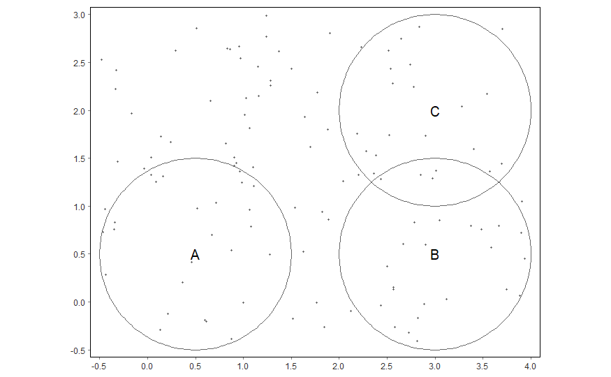

```r
tm_shape(circles_sf) +
  tm_borders() +
  tm_text("circle_id") +
tm_shape(pts_sf) +
  tm_dots(col = "dimgray") +
tm_grid(labels.show = TRUE, lines = FALSE)
```

## Identify the points in Circle A

Next we identify the points in circle A using a spatial predicate function (st_intersects). We could also copy the points in Cirlce A with st_intersection(), but there are times when you don’t need or want to make copies of the data.

```r
circle_a_sf <- circles_sf |> filter(circle_id == "A")

pt_in_circle_a_yn_mat <- pts_sf |>
  st_intersects(circle_a_sf,
                sparse = FALSE)

head(pt_in_circle_a_yn_mat)
```

```
      [,1]
[1,] FALSE
[2,]  TRUE
[3,] FALSE
[4,] FALSE
[5,] FALSE
[6,] FALSE
```

Since we have a column of TRUE/FALSE values, we can subset those features using the dplyr `filter` function:

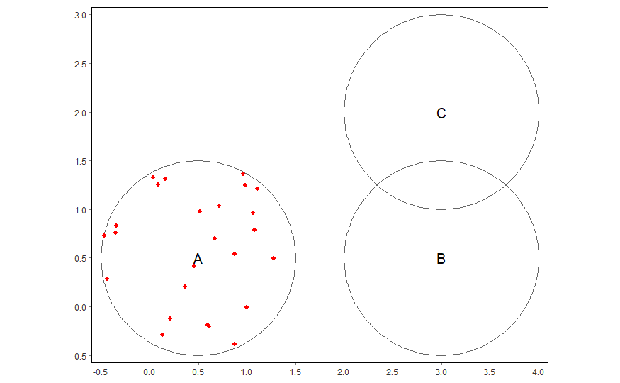

```r
## Copy the points in circle A to a new object. Note in the filter expression
## we use square bracket notation to pull out the first column of the matrix

a_pts_sf <- pts_sf |>
  filter(pt_in_circle_a_yn_mat[,1])

## Plot to verify
tm_shape(circles_sf) +
  tm_borders() +
  tm_text("circle_id") +
tm_shape(a_pts_sf) +
  tm_dots(col = "red", size = 0.1) +
tm_grid(labels.show = TRUE, lines = FALSE)
```

## CHALLENGE: How many points in cirlce B?

[Answer](https://bit.ly/3xwk0xV)

```r
## Your answer here
```

## CHALLENGE: Plot the points that fall within Circle B *and* Circle C

[Answer](https://bit.ly/3yvJk8H)

```r
## Your answer here
```

## CHALLENGE: How many points don’t fall in any circle?

[Answer](https://bit.ly/2VCUfz3)

```r
## Your answer here
```

## CHALLENGE: Plot the points that lie within 0.25 map units of a circle, but are not contained within the circle

[Answer](https://bit.ly/3xsXgyR)

```r
## Your answer here
```

# Plot the Points of Interest that Fall within the Upper Merced Subbasin

Next, we’ll apply what we learned to find the Yosemite Points-of-Interest that fall within the Upper Merced HUB-8 Subbasin.

## Import the Watersheds

Start by importing the planning watershed units from [calw221](https://frap.fire.ca.gov/mapping/gis-data/):

```r
## Import the planning watersheds
gpkg_watershd_fn <- "./data/yose_watersheds.gpkg"
yose_watersheds_sf <- st_read(gpkg_watershd_fn, layer="calw221")
## View attribute table
yose_watersheds_sf |> st_drop_geometry() |> slice(1:6)
```

| CALWNUM | HU | RBUASPW | HRNAME | HUNAME | RBNAME | HBPANAME | CDFSPWNAME | CDFPWSNAME | ACRES | HUC_8 | HUC_8_NAME |
| --- | --- | --- | --- | --- | --- | --- | --- | --- | --- | --- | --- |
| 8631.400101 | 31 | 8631400101 | North Lahontan | WEST WALKER RIVER | Lahontan | North Lahontan | Headwaters West Walker River | Cascade Creek | 6083.05 | 16050302 | WEST_WALKER-CA,NV |
| 8630.400204 | 30 | 8630400204 | North Lahontan | EAST WALKER RIVER | Lahontan | North Lahontan | Buckeye Creek | Upper Buckeye Creek | 9890.68 | 16050301 | EAST_WALKER-CA,NV |
| 8631.400104 | 31 | 8631400104 | North Lahontan | WEST WALKER RIVER | Lahontan | North Lahontan | Headwaters West Walker River | Kirkwood Creek | 6770.62 | 16050302 | WEST_WALKER-CA,NV |
| 6536.510101 | 36 | 6536510101 | San Joaquin | TUOLUMNE RIVER | Central Valley | San Joaquin | Huckleberry Lake | East Fork Cherry Creek | 12641.80 | 18040009 | UPPER_TUOLUMNE |
| 6536.600801 | 36 | 6536600801 | San Joaquin | TUOLUMNE RIVER | Central Valley | San Joaquin | Falls Creek | Upper Jack Main Canyon | 8838.88 | 18040009 | UPPER_TUOLUMNE |
| 8630.400301 | 30 | 8630400301 | North Lahontan | EAST WALKER RIVER | Lahontan | North Lahontan | Twin Lakes | Horse Creek | 7698.36 | 16050301 | EAST_WALKER-CA,NV |

```r
## Plot results
tmap_mode("plot")
```

```
tmap mode set to plotting
```

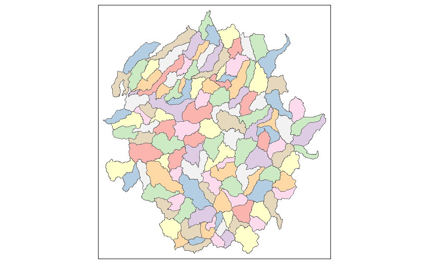

```r
tm_shape(yose_watersheds_sf) +
  tm_polygons("MAP_COLORS", palette = "Pastel1")
```

Note the keyword `MAP_COLORS` tells tmap to select colors at random such that adjacent polygons have different colors.

## Lump the Planning Watersheds into HUC-8 Subbasins

Next we’ll group the little planning watersheds into bigger “HUC-8” subbasins. This is easy because there is a column for the HUC 8 id number (`HUC_8`) and name (`HUC_8_NAME`).

```r
yose_huc8_sf <- yose_watersheds_sf |>
  group_by(HUC_8) |>
  summarise(HUC_8_NAME = first(HUC_8_NAME), num_pws = n())

yose_huc8_sf
```

```
Simple feature collection with 6 features and 3 fields
Geometry type: POLYGON
Dimension:     XY
Bounding box:  xmin: 1383.82 ymin: -61442.93 xmax: 81596.71 ymax: 26405.66
Projected CRS: NAD83 / California Albers
```

| HUC_8 | HUC_8_NAME | num_pws | geom |
| --- | --- | --- | --- |
| 16050301 | EAST_WALKER-CA,NV | 5 |  |
| 16050302 | WEST_WALKER-CA,NV | 2 |  |
| 18040006 | UPPER_SAN_JOAQUIN | 6 |  |
| 18040008 | UPPER_MERCED | 47 |  |
| 18040009 | UPPER_TUOLUMNE | 60 |  |
| 18090101 | MONO_LAKE-CA,NV | 7 |  |

A convenient feature of `group_by()` is that when applied to a simple feature data frame it will also spatially aggregate (i.e., union) the features based on common values in the grouping column. Plot to verify:

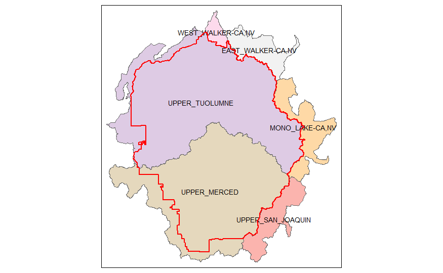

```r
epsg_utm11n_nad83 <- 26911
yose_bnd_utm <- st_read(dsn="./data", layer="yose_boundary") |>
  st_transform(epsg_utm11n_nad83)
tm_shape(yose_huc8_sf) +
  tm_polygons("MAP_COLORS", palette = "Pastel1") +
  tm_text("HUC_8_NAME", size = 0.7) +
tm_shape(yose_bnd_utm) +
  tm_borders(col = "red", lwd = 2)
```

## Extract Upper Merced HUC-8 Subbasin

Next, pull out just the Upper Merced subbasin and save it as a separate object:

```r
## Filter out just the Upper Merced Subbasin
merced_huc8_sf <- yose_huc8_sf |>
  filter(HUC_8_NAME == "UPPER_MERCED")
merced_huc8_sf
```

```
Simple feature collection with 1 feature and 3 fields
Geometry type: POLYGON
Dimension:     XY
Bounding box:  xmin: 2242.555 ymin: -61305.46 xmax: 65367.14 ymax: -12528.6
Projected CRS: NAD83 / California Albers
```

|  | HUC_8 | HUC_8_NAME | num_pws | geom |
| --- | --- | --- | --- | --- |
| 1 | 18040008 | UPPER_MERCED | 47 |  |

## Import the Points-of-Interest

Import the Yosemite POIs:

```r
## Import points of interest
yose_poi_utm <- st_read(dsn="./data", layer="yose_poi") |>
  select(OBJECTID, POINAME, POILABEL, POITYPE)
```

## Identify Intersecting Points-of-Interest

Find out which POIs intersect the Upper Merced subbasin with `st_intersects()`:

```r
try(merced_poi <- yose_poi_utm |> st_intersects(merced_watershed))
```

```
Error in st_geos_binop("intersects", x, y, sparse = sparse, prepared = prepared,  :
  object 'merced_watershed' not found
```

```r
merced_huc8_utm_sf <- merced_huc8_sf |>
  st_transform(st_crs(yose_poi_utm))
```

Try the intersection test again:

```r
yose_poi_merced_mat <- yose_poi_utm |> st_intersects(merced_huc8_utm_sf, sparse=FALSE)
head(yose_poi_merced_mat)
```

```
     [,1]
[1,] TRUE
[2,] TRUE
[3,] TRUE
[4,] TRUE
[5,] TRUE
[6,] TRUE
```

## CHALLENGE: How many points-of-interest fall within the Upper Merced subbasin?

*Hint 1*: This is equivalent to asking how many TRUE values there are in the first column of `yose_poi_merced_mat`.

*Hint 2*: To get the first column of a matrix `x`, use `x[ , 1]`.

[Answer](https://bit.ly/3rEOnzn)

```r
## Your answer here
```

## Subset the POIs that fall within the Upper Merced Subbasin

To extract the POIs in the Upper Merced subbasin, we can feed the first column of `yose_poi_merced_mat` into `filter()` (which expects TRUE/FALSE values):

```r
## Extract the points that intersect the subbasin to a new sf object
merced_poi_utm <- yose_poi_utm |>
  filter(yose_poi_merced_mat[,1])
```

## Plot the Intersection

Plot to visually verify the results:

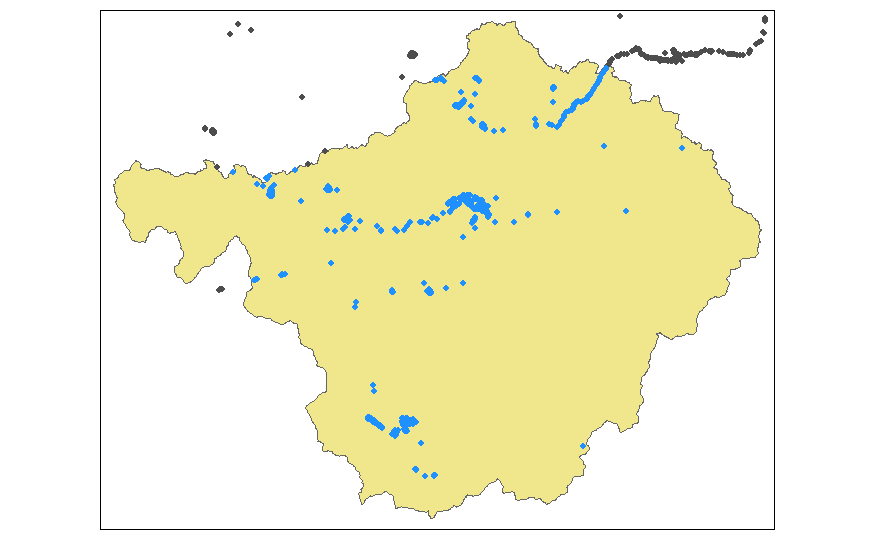

```r
## Plot
tm_shape(merced_huc8_utm_sf) +
  tm_polygons(col = "khaki") +
tm_shape(yose_poi_utm) +
  tm_dots(size = 0.1, col = "gray30") +
tm_shape(merced_poi_utm) +
  tm_dots(size = 0.1, col = "dodgerblue")
```

## CHALLENGE: How many YNP POIs fall witin the Upper Tuolumne HUC-8 subbasin?

[Answer](https://bit.ly/3AdasK6)

```r
## Your answer here
```

## End

Congratulations, you’ve completed another Notebook!

To view your Notebook at HTML, save it (again), then click the ‘Preview’ button in the RStudio toolbar.